# Laboratorio 3.1: Clustering

Andrés Abeliuk, Hernán Sarmiento, Cinthia Sánchez, Jorge Ortiz

Octubre 2022

## Nombres

- Benjamín Vega
- Samuel Chávez

# Instrucciones

1. Trabajen en equipos de dos personas. Salvo excepciones, no se corregirá entregas con menos de dos integrantes.
2. Modifique este archivo `.ipynb` agregando sus respuestas donde corresponda.
3. El formato de entrega para esta actividad es un archivo **html**. Genere un archivo HTML usando jupyter (ver tutorial 2) y súbalo a U-Cursos. Basta con que **uno de los integrantes haga la entrega**. Si ambos hacen una entrega en U-Cursos, se revisará cualquiera de éstas.

## Preguntas teóricas

### Pregunta 1

Verdadero o Falso (si la afirmación es falsa justifique):

1. El algoritmo DBSCAN se caracteriza por generar grupos a partir de centroides iniciales.

**Respuesta:** Falso. El algoritmo DBSCAN se caracteriza por generar grupos por la densidad de puntos en un radio.

2. El único método para validar clusters es mediante la estructura de los grupos formados, método conocido como validacion interna.

**Respuesta:** Falso, tambien se puede evaluar por validación externa. 3. Los métodos de clustering pueden servir para encontrar outliers.

**Respuesta:** Verdadero

## Preguntas practicas

Un amante de los pingüinos ha ido a la Antártica a recorrer las islas Biscoe, Dream y Torgersen en busca de su ave favorita. Cada vez que encontró un pingüino, anotó su sexo, su peso, la longitud de sus aletas y la longitud y profundidad de su pico.

Luego de su travesía, esta persona nos ha encargado averiguar cuántos tipos de pingüinos encontró. El desafío de este laboratorio será descubrir mediante Clustering las especies de los pingüinos de los datos recolectados.

Ejecute el siguiente código para cargar el dataset:

```python
import pandas as pd
import numpy as np
df = pd.read_csv("https://ortizfuentes.com/datasets/penguins_dataset.csv", sep=",")
df.head()
```

|  | island | bill_length_mm | bill_depth_mm | flipper_length_mm | body_mass_g | sex |
| --- | --- | --- | --- | --- | --- | --- |
| 0 | Torgersen | 39.1 | 18.7 | 181.0 | 3750.0 | male |
| 1 | Torgersen | 39.5 | 17.4 | 186.0 | 3800.0 | female |
| 2 | Torgersen | 40.3 | 18.0 | 195.0 | 3250.0 | female |
| 3 | Torgersen | 36.7 | 19.3 | 193.0 | 3450.0 | female |
| 4 | Torgersen | 39.3 | 20.6 | 190.0 | 3650.0 | male |

### Pregunta 2

Convierta la información categórica en información numérica. Puede usar la técnica One Hot Encoding. Guarde un DataFrame con toda la información numérica en una variable con nombre X.

```python
df = pd.read_csv("https://ortizfuentes.com/datasets/penguins_dataset.csv", sep=",")
X = pd.get_dummies(df[['sex', 'island']])
df = df.drop(['sex','island'], axis = 1)
X = pd.concat([df, X],axis=1)
X.head()
```

|  | bill_length_mm | bill_depth_mm | flipper_length_mm | body_mass_g | sex_female | sex_male | island_Biscoe | island_Dream | island_Torgersen |
| --- | --- | --- | --- | --- | --- | --- | --- | --- | --- |
| 0 | 39.1 | 18.7 | 181.0 | 3750.0 | 0 | 1 | 0 | 0 | 1 |
| 1 | 39.5 | 17.4 | 186.0 | 3800.0 | 1 | 0 | 0 | 0 | 1 |
| 2 | 40.3 | 18.0 | 195.0 | 3250.0 | 1 | 0 | 0 | 0 | 1 |
| 3 | 36.7 | 19.3 | 193.0 | 3450.0 | 1 | 0 | 0 | 0 | 1 |
| 4 | 39.3 | 20.6 | 190.0 | 3650.0 | 0 | 1 | 0 | 0 | 1 |

### Pregunta 3

Primero intentaremos encontrar la cantidad de especies de pingüinos en los datos usando K-Means. Ejecute el siguiente código:

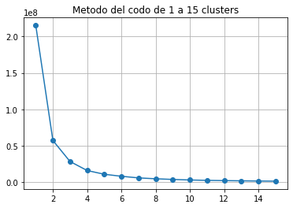

```python
import matplotlib.pyplot as plt
from sklearn.cluster import KMeans

sse = []

clusters = list(range(1, 16))
for k in clusters:
    kmeans = KMeans(n_clusters=k).fit(X)
    sse.append(kmeans.inertia_)

plt.plot(clusters, sse, marker="o")
plt.title("Metodo del codo de 1 a 15 clusters")
plt.grid(True)
plt.show()
```

**1.** ¿Cuántos clusters propone usar para este dataset? Justifique su elección y recuerde que hay varias respuestas posibles.

> Respuesta: Mediante el metodo del codo utilizaremos 2 clusters para el data set

**2.** Entrene un modelo de K-Means usando el número de clusters que eligió en la pregunta anterior e imprima las asignaciones de clusters para cada dato.

```python
from sklearn.cluster import KMeans

kmeans = KMeans(n_clusters=2, n_init=20, max_iter=50, random_state=1)
kmeans.fit(X) #`fit_predict` entrena el modelo y devuelve las predicciones
y_pred = kmeans.labels_ #kmeans.predict(rates)
counts = np.bincount(y_pred)
counts
```

```
array([203, 130])
```